# Human Activity Recognition using Machine Learning Algorithms

Guimiao Zhang

## Executive Summary

Based on the dataset provide by [Human Activity Recognition](http://groupware.les.inf.puc-rio.br/har), a series of machine learning algorithms have been performed to train a model for recognizing human activities.

Following steps have been conducted:

- loading the data;
- exploring & processing the training data as needed;
- building the models & choosing parameters as needed using the training;
- testing the model using the testing data.

## Data loading

```r
library(caret)
library(class)
library(mclust)
library(dplyr)
train <- 'https://d396qusza40orc.cloudfront.net/predmachlearn/pml-training.csv'
test <- 'https://d396qusza40orc.cloudfront.net/predmachlearn/pml-testing.csv'
if (!file.exists('data')) {dir.create('data')}
if (!file.exists('data/train.csv')) {download.file(train, destfile = 'data/train.csv')}
if (!file.exists('data/test.csv')) {download.file(test, destfile = 'data/test.csv')}
library(data.table)
train <- fread('data/train.csv') # training cases
test <- fread('data/test.csv') # testing cases
```

## Data exploring & processing

#### General idea

Look at the dimension, classification variable, and basic summary of the dataset.

```r
which(colnames(train) == 'classe'); summary(train$classe)
```

```
## [1] 160
```

```
##    Length     Class      Mode
##     19622 character character
```

```r
dim(train)
```

```
## [1] 19622   160
```

```r
# summary(train); head(train)
```

#### Data cleaning

1. There are lots of columns containing `NA`s, try to remove columns with more than 60% of `NA`s.
2. As 1st to 7th columns containing the ID information rather than features of the activities, remove those from the model.
3. Factorize the activity classification variable `classe`.

```r
nastoomany <- function(vector) {
    # prepare for removing cols w/ too many nas
    thres <- sum(is.na(vector)) / length(vector)
    return(thres > 0.6) # can be 0.5, 0.6, etc, user's choice
}

colsnonfeatures <- 1:7 # cols w/ only id info but not features
nas <- sapply(train, nastoomany)
dat <- train[, c(colnames(train)[!nas]), with = F] # remove na > 60% features
dat <- dat[, -colsnonfeatures, with = F] # remove cols w/ only id info
dat <- dat[, classe := lapply(.SD, factor), .SDcols = 'classe'] # factor classes
dim(dat)
```

```
## [1] 19622    53
```

```r
# summary(dat)
which(colnames(dat) == 'classe')
```

```
## [1] 53
```

#### Spliting the training cases into training set & validating set

```r
set.seed(4)
# split dataset into training : validating = 7:3
validates <- createDataPartition(y = dat$classe, p = 0.3, list = F)
training <- dat[!validates, ]
validating <- dat[validates, ]
dim(training); dim(validating)
```

```
## [1] 13733    53
```

```
## [1] 5889   53
```

## Building models

#### Reduce the dimensionality

```r
# 53 features, consider PCAs reduce dimensionality
pcas <- preProcess(training[, -53], 'pca', thresh = 0.9)
trains <- predict(pcas, training)
vals <- predict(pcas, validating)
pcas
```

```
## Created from 13733 samples and 52 variables
##
## Pre-processing:
##   - centered (52)
##   - ignored (0)
##   - principal component signal extraction (52)
##   - scaled (52)
##
## PCA needed 18 components to capture 90 percent of the variance
```

```r
# pcas$rotation
```

#### Random forest

```r
fit <- train(classe ~ ., data = trains, method = 'rf')
trainpred <- predict(fit, trains)
valspred <- predict(fit, vals)
valres <- confusionMatrix(valspred, validating$classe)
fit$bestTune; fit$results
```

```
##   mtry
## 1    2
```

```
##   mtry  Accuracy     Kappa  AccuracySD     KappaSD
## 1    2 0.9594213 0.9486488 0.003191349 0.004070336
## 2   10 0.9498776 0.9365845 0.003398946 0.004331381
## 3   18 0.9370161 0.9203198 0.004960969 0.006314033
```

```r
valres$overall['Accuracy']
```

```
##  Accuracy
## 0.9696043
```

The best tuning for the number of variables randomly sampled as candidates at each split is 2 where the best accuracy is chosen as the metric and 500 trees were built.

#### Support vector machines

```r
# svm
fit1 <- train(classe ~ ., data = trains, method = 'svmRadial')
fit1$bestTune; fit1$results
```

```
##        sigma C
## 3 0.03702593 1
```

```
##        sigma    C  Accuracy     Kappa  AccuracySD     KappaSD
## 1 0.03702593 0.25 0.8109860 0.7599545 0.007094743 0.008832073
## 2 0.03702593 0.50 0.8440462 0.8020239 0.006749605 0.008458288
## 3 0.03702593 1.00 0.8750352 0.8415766 0.006380655 0.008034042
```

```r
trainpred1 <- predict(fit1, trains)
valspred1 <- predict(fit1, vals)
valres1 <- confusionMatrix(valspred1, validating$classe)
valres1$overall['Accuracy']
```

```
##  Accuracy
## 0.8731533
```

#### K-nearest neighbor

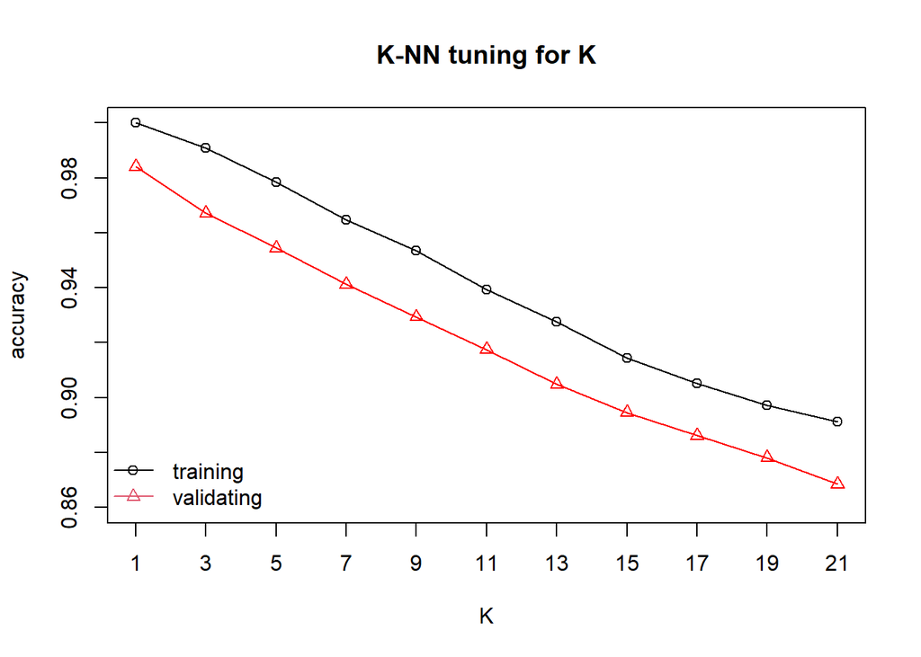

Accuracies vs K for KNN models

```r
# knn
ks <- seq(1, 21, 2) # try to tune the number of nearest neighbor
tacc <- c(); vacc <- c()
for(i in 1:length(ks)) {
    tpred <- knn(trains[, -1], trains[, -1], trains$classe, k = ks[i])
    vpred <- knn(trains[, -1], vals[, -1], trains$classe, k = ks[i])
    tacc[i] <- sum(tpred == trains$classe) / length(tpred)
    vacc[i] <- sum(vpred == vals$classe) / length(vpred)
}

plot(ks, tacc, xaxt = 'n', ylim = c(0.86, 1), xlab = 'K', ylab = 'accuracy', type = 'o', main = 'K-NN tuning for K')
points(ks, vacc, col = 'red', pch = 2)
lines(ks, vacc, col = 'red')
axis(1, at = ks, label = ks)
legend('bottomleft', bty = 'n', legend = c('training', 'validating'), pch = 1:2, lty = 1, col = 1:2)
```

As shown in the figure , `k=1` is chosen for best accuracy.

```r
trainpred2 <- knn(trains[, -1], trains[, -1], trains$classe, k = 1)
valspred2 <- knn(trains[, -1], vals[, -1], trains$classe, k = 1)
```

#### Majority vote

As different machine learning algorithm may classify the activities into different labels, simple majority vote is adopted here.

```r
dftrain <- data.frame(trainpred, trainpred1, trainpred2)
dfval <- data.frame(valspred, valspred1, valspred2)
tvotepred <- apply(dftrain, 1, majorityVote) %>% simplify2array
vvotepred <- apply(dfval, 1, majorityVote) %>% simplify2array
tvoteacc <- sum(tvotepred[3,] == trains$classe) / length(trains$classe) # train acc.
vvoteacc <- sum(vvotepred[3,] == vals$classe) /length(vals$classe) # val. acc.
```

#### Brief summary

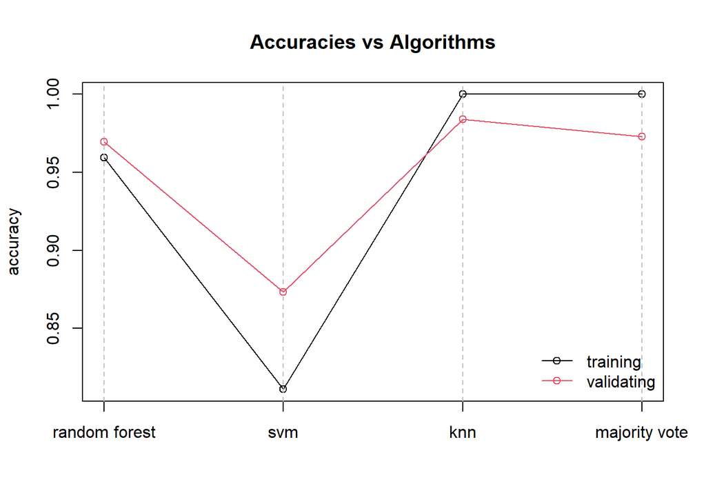

Accuracies vs Algorithms

```r
trainaccs <- c(fit$results$Accuracy[1], fit1$results$Accuracy[1], tacc[1], tvoteacc)
valaccs <- c(valres$overall['Accuracy'], valres1$overall['Accuracy'], vacc[1], vvoteacc)
plot(trainaccs, xaxt = 'n', type = 'o', xlab = '', ylab = 'accuracy', main = 'Accuracies vs Algorithms')
axis(1, at = 1:4, label = c('random forest', 'svm', 'knn', 'majority vote'))
abline(v = 1:4, lty = 2, col = 'grey')
points(valaccs, col = 2)
lines(valaccs, col = 2)
legend('bottomright', bty = 'n', legend = c('training', 'validating'), pch = 1, lty = 1, col = 1:2)
```

From figure , we can see that for this specific dataset, SVM model built here does not works well.

Accuracies for different algorithms on training set & validating set

[output not shown]

## Prediction on testing cases

1. Process the dataset as done for training cases

```r
test[, c(colnames(train)[nas]):= NULL] # remove cols w/ too many nas
tests <- predict(pcas, test[, -colsnonfeatures, with = F]) # change to pcas
```

2. Predictions

```r
# random forest
testpred <- predict(fit, tests)

# svm
testpred1 <- predict(fit1, tests)

# knn
testpred2 <- knn(trains[, -1], tests[, -1], trains$classe, k = 1)

# majority vote for prediction
preds <- data.frame(testpred, testpred1, testpred2)
pred <- apply(preds, 1, majorityVote) %>% simplify2array
pred <- pred[3, ] %>% simplify2array %>% factor

output <- cbind('random forest' = testpred,
                'svm' = testpred1,
                'knn'= testpred2,
                'majority vote'= pred)
output <- apply(output, 1, factor, levels = 1:5, labels = LETTERS[1:5])
colnames(output) <- paste0('problem_', 1:20)
print('The predictions for the testing cases are:')
output
```

```
## [1] "The predictions for the testing cases are:"
##               problem_1 problem_2 problem_3 problem_4 problem_5 problem_6
## random forest "B"       "A"       "B"       "A"       "A"       "E"
## svm           "B"       "A"       "C"       "A"       "A"       "E"
## knn           "B"       "A"       "B"       "A"       "A"       "E"
## majority vote "B"       "A"       "B"       "A"       "A"       "E"
##               problem_7 problem_8 problem_9 problem_10 problem_11 problem_12
## random forest "D"       "B"       "A"       "A"        "B"        "C"
## svm           "D"       "B"       "A"       "A"        "B"        "C"
## knn           "D"       "B"       "A"       "A"        "B"        "C"
## majority vote "D"       "B"       "A"       "A"        "B"        "C"
##               problem_13 problem_14 problem_15 problem_16 problem_17 problem_18
## random forest "B"        "A"        "E"        "E"        "A"        "B"
## svm           "B"        "A"        "E"        "E"        "A"        "B"
## knn           "B"        "A"        "E"        "E"        "A"        "B"
## majority vote "B"        "A"        "E"        "E"        "A"        "B"
##               problem_19 problem_20
## random forest "B"        "B"
## svm           "B"        "B"
## knn           "B"        "B"
## majority vote "B"        "B"
```